# Project #2

Jakub Bednarz

First, the libraries:

```r
library(ggplot2)
library(ggridges)
library(glmnet)
library(mlr3verse)
library(mlr3fselect)
lgr::get_logger("mlr3")$set_threshold("warn")

set.seed(9000)
```

We are going to operate on a table from `cancer.RData`:

```r
df = load("cancer.RData")
data.train = as.data.frame(data.train)
data.test = as.data.frame(data.test)

y = data.train[,"Y"]
X = data.train[,-grep("Y", colnames(data.train))]
X = as.matrix(X)
```

## Part 1

We are to, in general, analyze the features in the dataset.

```r
table(apply(X, 2, class))
```

```
##
## numeric
##   17737
```

```r
sum(is.na(X))
```

```
## [1] 0
```

As expected, all the features are numerical; also, all the features are non-N/A so we need not imput any values. Next, we select 500 features by largest variance and plot the distribution of their covariances. I assume we are to plot the distribution of all their covariances at once and not 500 violin plots for each feature since that would be silly.

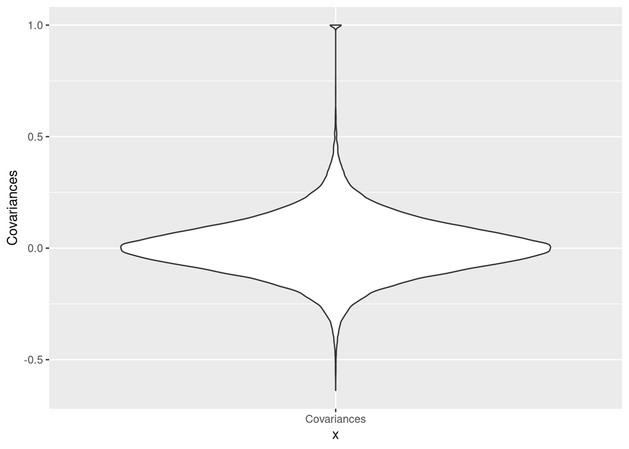

```r
variances = apply(X, 1, var)
nfeatures = 500
features = colnames(X)[order(variances, decreasing = TRUE)[1:500]]
feat_columns = X[,features]

covariances = cor(feat_columns, feat_columns)
cov_df = data.frame(as.vector(covariances))
colnames(cov_df) <- c("Covariances")

ggplot() +
  geom_violin(data = cov_df, aes(x = "Covariances", y = Covariances))
```

I must admit I have no idea how to interpret this plot.

## Part 2

Elastic nets are, essentially, supposed to overcome certain limitations of ridge ($L^2$) and lasso ($L^1$) regularization methods. The first one usually works best when $y$ depends on many features with similar coefficients; the second one is better when $y$ depends on a small number of features. Of course, in many cases neither of these is really the case, and in any case we don’t know *a priori* which one to pick. The idea is then to combine these two regularization methods *into a single one*, as in $\|y - Ax \|^2 + \lambda(\alpha \| x \|_1 + (1-\alpha) \| x \|_2^2)$; $\alpha = 0$ recovers ridge, and $\alpha = 1$ recovers lasso. This, however, comes at a cost: though $\lambda$ can be fitted automatically, $\alpha$ must be “guessed”; thankfully *usually* we can pick sparsely from the ridge end of the spectrum (say $0.25$, $0.5$, $0.75$) and more densely from the lasso end ($0.8$, $0.9$, $0.99$ etc.) and the sparsity at the ridge end doesn’t affect the results that much. Thus the elastic nets are flexible and efficient replacements for standard $L^1$ or $L^2$-regularized linear models.

## Parts 3-4

I will use `mlr3` package, chiefly because I haven’t used it before and it’s supposedly good.

```r
task = as_task_regr(data.train, target = "Y")
measure = msr("regr.mse")
cv = rsmp("cv", folds = 5)
```

### Feature selection

First, we want to perform feature selection, as we may conjecture that of the 18k features most are utterly useless. Not only will the training process be quicker, potentially the scores will be better even though information is lost, since for example RFs will be able to “focus better on relevant variables.” There are many ways of approaching this (Genuer, Poggi, and Tuleau-Malot (2010)), but because we don’t necessarily need sophistication and I don’t have the necessary compute. As for the more simple approaches, elastic net automatically selects features due to $L^1$ regularization, and RFs compute variable importance. One could also check the variance of the variables, somewhat in the vein of performing dimensionality reduction via PCA. I want to investigate the variable importance, especially whether it’s “stable” across different runs and different CV folds. We will perform a $10$-fold CV and plot normalized VI means and medians.

```r
vi_cv = rsmp("cv", folds = 10)
vi_rf = lrn("regr.ranger", importance = "impurity")
vi_res = resample(task, vi_rf, vi_cv, store_models = TRUE)
```

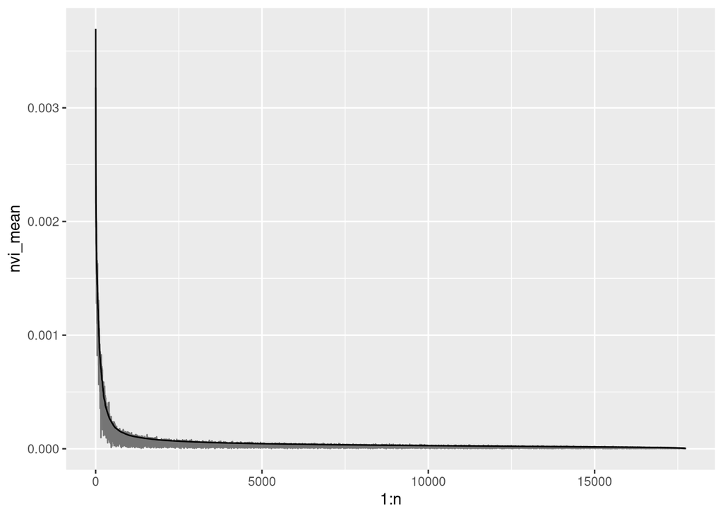

```r
normed_vi = sapply(vi_res$learners, function(m) {
  vi = as.data.frame(m$importance())
  ord = order(rownames(vi))
  return((vi/sum(vi))[ord,])
})

nvi_mean = apply(normed_vi, 1, mean)
nvi_quant = apply(normed_vi, 1, quantile)
nvi_med = nvi_quant[3,]

nvi_mean_ord = order(nvi_mean, decreasing = TRUE)
nvi_mean = nvi_mean[nvi_mean_ord]
nvi_med = nvi_med[nvi_mean_ord]

n = length(nvi_mean)

ggplot() +
  geom_line(aes(x = 1:n, y = nvi_mean)) +
  geom_line(aes(x = 1:n, y = nvi_med), alpha = 0.5)
```

These results are a *bit* concerning, since they imply that VI mean is not necessarily *the* measure to assess the variables by, since the medians are quite different from them. Let’s see whether different quantiles are as mutually-fluctuating:

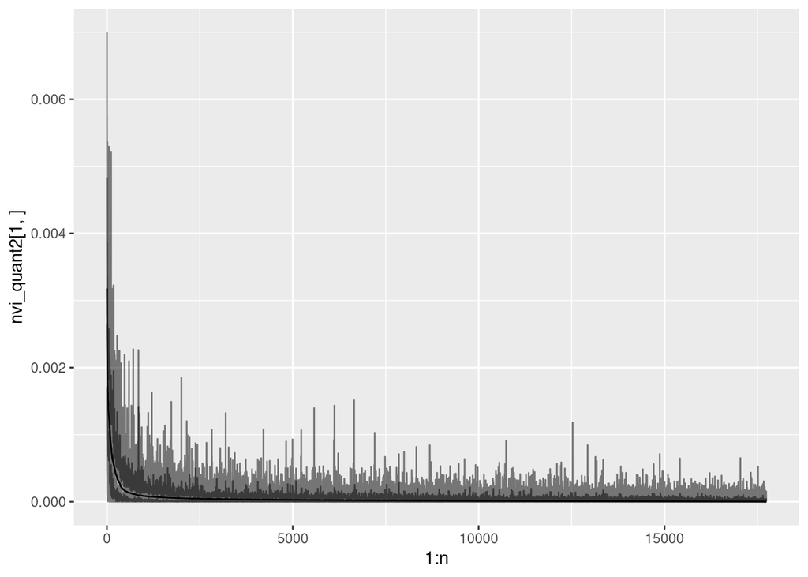

```r
nvi_quant2 = apply(normed_vi, 1, quantile)
nvi_quant2_ord = order(nvi_quant2[3,], decreasing = TRUE)
nvi_quant2 = nvi_quant2[,nvi_quant2_ord]

ggplot() +
  geom_line(aes(x = 1:n, y = nvi_quant2[1,]), alpha = 0.5) +
  geom_line(aes(x = 1:n, y = nvi_quant2[2,]), alpha = 0.5) +
  geom_line(aes(x = 1:n, y = nvi_quant2[3,])) +
  geom_line(aes(x = 1:n, y = nvi_quant2[4,]), alpha = 0.5) +
  geom_line(aes(x = 1:n, y = nvi_quant2[5,]), alpha = 0.5)
```

They are still fluctuating; let’s perhaps now look at what the lasso models think should be the optimal value of non-zero terms:

```r
lasso_res = cv.glmnet(X, y, alpha = 1)
quantile(lasso_res$nzero)
```

```
##     0%    25%    50%    75%   100%
##   0.00  25.75 164.50 448.50 631.00
```

The median is $<200$. For one, I didn’t think that there would be so much variability, perhaps the other terms are completely useless and the mean values they attain are essentially due to outliers. Taking a further look at the graph with VI means and medians, around $k = 500$ the median starts to “lift off” from 0; having all this and the performance considerations in mind, although the decision is far more “heurestic” than I’d wish, I think it’s safe to run an RF and pick, say, top 500 features based on VI.

```r
rf_filt_learner = lrn("regr.ranger", importance = "impurity")
rf_filt = flt("importance", learner = rf_filt_learner)
rf_filt$calculate(task)
selected = as.data.frame(as.data.table(rf_filt))[1:500, "feature"]
reduced_task = task$clone()$select(selected)
```

As for the models themselves, we will “simply” run a random grid search with some suitable hyperparameter distributions with $5$-fold CV and run it into stagnation.

### Elastic net model

```r
enet_learner = lrn("regr.glmnet")
enet_hypers = ps(
  alpha = p_dbl(1e-5, 0.8),
  nlambda = p_int(lower = 1, upper = 256)
)
enet_term = trm("stagnation")

enet_inst = TuningInstanceSingleCrit$new(
  task = reduced_task,
  learner = enet_learner,
  resampling = cv,
  measure = measure,
  search_space = enet_hypers,
  terminator = enet_term
)

enet_tuner = tnr("random_search")
enet_tuner$optimize(enet_inst)
```

```
## INFO  [20:51:06.871] [bbotk] Starting to optimize 2 parameter(s) with '<OptimizerRandomSearch>' and '<TerminatorStagnation> [iters=10, threshold=0]'
## INFO  [20:51:06.884] [bbotk] Evaluating 1 configuration(s)
## INFO  [20:51:17.158] [bbotk] Result of batch 1:
## INFO  [20:51:17.160] [bbotk]      alpha nlambda   regr.mse                                uhash
## INFO  [20:51:17.160] [bbotk]  0.7837657       6 0.01234338 d0fcdd37-53f5-43bd-bf37-814db0eda0fb
## INFO  [20:51:17.164] [bbotk] Evaluating 1 configuration(s)
## INFO  [20:51:23.099] [bbotk] Result of batch 2:
## INFO  [20:51:23.103] [bbotk]       alpha nlambda   regr.mse                                uhash
## INFO  [20:51:23.103] [bbotk]  0.03940622      79 0.01616247 5e288b07-4621-49fb-a4ba-ca5783ac64fb
## INFO  [20:51:23.109] [bbotk] Evaluating 1 configuration(s)
## INFO  [20:51:32.165] [bbotk] Result of batch 3:
## INFO  [20:51:32.167] [bbotk]      alpha nlambda   regr.mse                                uhash
## INFO  [20:51:32.167] [bbotk]  0.5578809      47 0.01203398 a3b67760-1a23-4594-ae8c-c0088deb745f
## INFO  [20:51:32.170] [bbotk] Evaluating 1 configuration(s)
## INFO  [20:51:33.857] [bbotk] Result of batch 4:
## INFO  [20:51:33.859] [bbotk]         alpha nlambda   regr.mse                                uhash
## INFO  [20:51:33.859] [bbotk]  0.0006605514     104 0.01853554 eb390d88-31cf-44f8-83d7-a51f8e5fdc62
## INFO  [20:51:33.862] [bbotk] Evaluating 1 configuration(s)
## INFO  [20:51:42.861] [bbotk] Result of batch 5:
## INFO  [20:51:42.863] [bbotk]      alpha nlambda   regr.mse                                uhash
## INFO  [20:51:42.863] [bbotk]  0.4875251     204 0.01205849 a9e8e29e-1688-4a62-8dad-8f4aec2ea91e
## INFO  [20:51:42.867] [bbotk] Evaluating 1 configuration(s)
## INFO  [20:51:50.700] [bbotk] Result of batch 6:
## INFO  [20:51:50.702] [bbotk]      alpha nlambda   regr.mse                                uhash
## INFO  [20:51:50.702] [bbotk]  0.1914581     119 0.01331722 9ec9fbc8-4003-49e9-81ee-8603426d0709
## INFO  [20:51:50.705] [bbotk] Evaluating 1 configuration(s)
## INFO  [20:51:58.904] [bbotk] Result of batch 7:
## INFO  [20:51:58.906] [bbotk]      alpha nlambda   regr.mse                                uhash
## INFO  [20:51:58.906] [bbotk]  0.2288875     223 0.01302178 c68a355d-1afd-4976-a861-2991f0ea2cf0
## INFO  [20:51:58.911] [bbotk] Evaluating 1 configuration(s)
## INFO  [20:52:05.769] [bbotk] Result of batch 8:
## INFO  [20:52:05.771] [bbotk]      alpha nlambda   regr.mse                                uhash
## INFO  [20:52:05.771] [bbotk]  0.2541491       3 0.01625046 b6fc7a11-7cfa-4e9e-9fa9-21088ce911b7
## INFO  [20:52:05.775] [bbotk] Evaluating 1 configuration(s)
## INFO  [20:52:13.422] [bbotk] Result of batch 9:
## INFO  [20:52:13.424] [bbotk]      alpha nlambda   regr.mse                                uhash
## INFO  [20:52:13.424] [bbotk]  0.3609864      10 0.01236947 210ff1fa-d05d-45ff-bc0b-57d8df82e0c6
## INFO  [20:52:13.427] [bbotk] Evaluating 1 configuration(s)
## INFO  [20:52:22.557] [bbotk] Result of batch 10:
## INFO  [20:52:22.559] [bbotk]      alpha nlambda   regr.mse                                uhash
## INFO  [20:52:22.559] [bbotk]  0.5260448     146 0.01204594 423e6ea5-5ee4-437f-8d22-2213a2878e8d
## INFO  [20:52:22.563] [bbotk] Evaluating 1 configuration(s)
## INFO  [20:52:32.253] [bbotk] Result of batch 11:
## INFO  [20:52:32.255] [bbotk]      alpha nlambda   regr.mse                                uhash
## INFO  [20:52:32.255] [bbotk]  0.7688627     141 0.01212405 70bb8bb6-7f9a-4c31-b1ad-ac60df458461
## INFO  [20:52:32.259] [bbotk] Evaluating 1 configuration(s)
## INFO  [20:52:41.399] [bbotk] Result of batch 12:
## INFO  [20:52:41.401] [bbotk]      alpha nlambda   regr.mse                                uhash
## INFO  [20:52:41.401] [bbotk]  0.6828803      64 0.01205835 3999d72c-bb92-46a9-a03b-d164c8465566
## INFO  [20:52:41.405] [bbotk] Evaluating 1 configuration(s)
## INFO  [20:52:49.854] [bbotk] Result of batch 13:
## INFO  [20:52:49.856] [bbotk]      alpha nlambda   regr.mse                                uhash
## INFO  [20:52:49.856] [bbotk]  0.3696258     240 0.01226838 ee01664f-2b55-469e-9cc5-1a1ba62e15a1
## INFO  [20:52:49.864] [bbotk] Finished optimizing after 13 evaluation(s)
## INFO  [20:52:49.865] [bbotk] Result:
## INFO  [20:52:49.866] [bbotk]      alpha nlambda learner_param_vals  x_domain   regr.mse
## INFO  [20:52:49.866] [bbotk]  0.5578809      47          <list[3]> <list[2]> 0.01203398
```

```
##        alpha nlambda learner_param_vals  x_domain   regr.mse
## 1: 0.5578809      47          <list[3]> <list[2]> 0.01203398
```

```r
enet_learner$param_set$values = enet_inst$result_learner_param_vals
```

I must note that, looking at the printouts, having selected the features made more lasso-like elastic nets not perform as well as they used to, i.e. now it doesn’t make sense to cut out features because we already did it once.

### Random forest

```r
rf_learner = lrn("regr.ranger", importance = "impurity")
rf_hypers = ps(
  num.trees = p_int(lower = 100, upper = 2048)
)
rf_term = trm("stagnation")

rf_inst = TuningInstanceSingleCrit$new(
  task = reduced_task,
  learner = rf_learner,
  resampling = cv,
  measure = measure,
  search_space = rf_hypers,
  terminator = rf_term
)

rf_tuner = tnr("random_search")
rf_tuner$optimize(rf_inst)
```

```
## INFO  [20:52:49.993] [bbotk] Starting to optimize 1 parameter(s) with '<OptimizerRandomSearch>' and '<TerminatorStagnation> [iters=10, threshold=0]'
## INFO  [20:52:50.001] [bbotk] Evaluating 1 configuration(s)
## INFO  [20:53:17.994] [bbotk] Result of batch 1:
## INFO  [20:53:17.996] [bbotk]  num.trees  regr.mse                                uhash
## INFO  [20:53:17.996] [bbotk]       1421 0.0112837 462052d0-cbf6-42fc-9c58-e91230dce865
## INFO  [20:53:17.999] [bbotk] Evaluating 1 configuration(s)
## INFO  [20:53:45.817] [bbotk] Result of batch 2:
## INFO  [20:53:45.819] [bbotk]  num.trees   regr.mse                                uhash
## INFO  [20:53:45.819] [bbotk]       1329 0.01128138 c070190a-10cc-49cf-9153-adb03d92231b
## INFO  [20:53:45.822] [bbotk] Evaluating 1 configuration(s)
## INFO  [20:54:12.079] [bbotk] Result of batch 3:
## INFO  [20:54:12.081] [bbotk]  num.trees   regr.mse                                uhash
## INFO  [20:54:12.081] [bbotk]       1326 0.01128671 1b530033-fbf4-49a4-9c9d-27baaae1bd92
## INFO  [20:54:12.084] [bbotk] Evaluating 1 configuration(s)
## INFO  [20:54:30.053] [bbotk] Result of batch 4:
## INFO  [20:54:30.056] [bbotk]  num.trees   regr.mse                                uhash
## INFO  [20:54:30.056] [bbotk]        941 0.01130653 f4161f46-0c27-4e19-a2f7-adf7d7b8723c
## INFO  [20:54:30.060] [bbotk] Evaluating 1 configuration(s)
## INFO  [20:55:04.910] [bbotk] Result of batch 5:
## INFO  [20:55:04.912] [bbotk]  num.trees   regr.mse                                uhash
## INFO  [20:55:04.912] [bbotk]       1853 0.01130128 1ecd70d5-a224-4136-a50f-ca785341bd25
## INFO  [20:55:04.915] [bbotk] Evaluating 1 configuration(s)
## INFO  [20:55:10.195] [bbotk] Result of batch 6:
## INFO  [20:55:10.196] [bbotk]  num.trees   regr.mse                                uhash
## INFO  [20:55:10.196] [bbotk]        281 0.01117274 6979f4f4-60be-45de-b5fe-7efebbe32af1
## INFO  [20:55:10.199] [bbotk] Evaluating 1 configuration(s)
## INFO  [20:55:46.221] [bbotk] Result of batch 7:
## INFO  [20:55:46.223] [bbotk]  num.trees   regr.mse                                uhash
## INFO  [20:55:46.223] [bbotk]       1770 0.01125992 75993cbf-0778-4400-9f17-fe50150539f2
## INFO  [20:55:46.226] [bbotk] Evaluating 1 configuration(s)
## INFO  [20:56:14.508] [bbotk] Result of batch 8:
## INFO  [20:56:14.509] [bbotk]  num.trees   regr.mse                                uhash
## INFO  [20:56:14.509] [bbotk]       1416 0.01127164 2718e69c-c69c-42f8-bb67-9b0a27310fb6
## INFO  [20:56:14.514] [bbotk] Evaluating 1 configuration(s)
## INFO  [20:56:57.846] [bbotk] Result of batch 9:
## INFO  [20:56:57.848] [bbotk]  num.trees  regr.mse                                uhash
## INFO  [20:56:57.848] [bbotk]       1932 0.0112751 10ca8c4e-2f22-414a-942d-40e48892f120
## INFO  [20:56:57.851] [bbotk] Evaluating 1 configuration(s)
## INFO  [20:57:29.396] [bbotk] Result of batch 10:
## INFO  [20:57:29.397] [bbotk]  num.trees   regr.mse                                uhash
```

[output cut: 14 more lines]

```
## INFO  [20:58:24.381] [bbotk] Result of batch 14:
## INFO  [20:58:24.383] [bbotk]  num.trees   regr.mse                                uhash
## INFO  [20:58:24.383] [bbotk]        752 0.01127767 764ab88e-dc7c-4d4a-819e-1199997a6f9a
## INFO  [20:58:24.389] [bbotk] Evaluating 1 configuration(s)
## INFO  [20:59:01.308] [bbotk] Result of batch 15:
## INFO  [20:59:01.310] [bbotk]  num.trees   regr.mse                                uhash
## INFO  [20:59:01.310] [bbotk]       1538 0.01123755 7f8d5581-cc44-43a8-b6ad-6450bb642fd5
## INFO  [20:59:01.314] [bbotk] Evaluating 1 configuration(s)
## INFO  [20:59:30.113] [bbotk] Result of batch 16:
## INFO  [20:59:30.114] [bbotk]  num.trees   regr.mse                                uhash
## INFO  [20:59:30.114] [bbotk]       1366 0.01130172 9c9d5fad-5b76-461b-9e82-ddcc108206d5
## INFO  [20:59:30.122] [bbotk] Finished optimizing after 16 evaluation(s)
## INFO  [20:59:30.123] [bbotk] Result:
## INFO  [20:59:30.124] [bbotk]  num.trees learner_param_vals  x_domain   regr.mse
## INFO  [20:59:30.124] [bbotk]        281          <list[3]> <list[1]> 0.01117274
```

```
##    num.trees learner_param_vals  x_domain   regr.mse
## 1:       281          <list[3]> <list[1]> 0.01117274
```

```r
rf_learner$param_set$values = rf_inst$result_learner_param_vals
```

### Summary

Let’s run the models (now with best parameters) again:

```r
resamp_enet = resample(reduced_task, enet_learner, cv)
res_enet = resamp_enet$score(measure)[,"regr.mse"]

resamp_rf = resample(reduced_task, rf_learner, cv)
res_rf = resamp_rf$score(measure)[,"regr.mse"]

res_df = data.frame(res_enet, res_rf)
colnames(res_df) = c("Elastic net", "Random forest")
res_df
```

```
##   Elastic net Random forest
## 1  0.01514041    0.01078054
## 2  0.01058001    0.01257926
## 3  0.01102834    0.01355877
## 4  0.01208935    0.00936865
## 5  0.01038857    0.01055015
```

```r
apply(res_df, 2, mean)
```

```
##   Elastic net Random forest
##    0.01184534    0.01136747
```

```r
apply(res_df, 2, sd)
```

```
##   Elastic net Random forest
##   0.001956256   0.001679138
```

To be frank, (1) there’s not that great a difference between them, (2) they seem to “swap positions” as I rerun it; I will pick the elastic net because they will output the predictions faster.

## Part 5

Now all that is left to be done is saving the results.

```r
enet_learner$train(reduced_task)
reduced_test = data.test[,selected]
predictions = enet_learner$predict_newdata(reduced_test)$response
save(predictions, file = "jb406103.RData")
```

Degenhardt, Frauke, Stephan Seifert, and Silke Szymczak. 2017. “Evaluation of variable selection methods for random forests and omics data sets.” *Briefings in Bioinformatics* 20 (2): 492–503. https://doi.org/10.1093/bib/bbx124.

Genuer, Robin, Jean-Michel Poggi, and Christine Tuleau-Malot. 2010. “Variable Selection Using Random Forests.” *Pattern Recognition Letters* 31 (14): 2225–36.